# *Was Breaking Up One Of The Oldest Rosters in Counter-Strike: Global Offensive A Good Idea?*

[figure not shown]

## By: Jared Shiao

## Introduction

[Counter-Strike: Global Offensive(CS:GO)](https://store.steampowered.com/app/730/CounterStrike_Global_Offensive/) is a first-person shooter released in 2012 on [Steam](https://store.steampowered.com/), the most popular videogame distribution hub for computer games. The objective of the game is to win rounds as a Counter-Terrorist or a Terrorist, a single match consists of 10 players split into 2 teams, with 30 rounds split into 2 15 round halves. The match goes until either a team reaches 16 round wins or until the full 30 rounds are played. At the start of the match, one team is assigned the Counter-Terrorists role, and the other is assigned Terrorists, and at halftime the roles swap. Though in many high-level tournaments and games, there's a possibility for overtime if the teams end up being tied at 15-15 after the full 30 rounds, in most cases, 6 more rounds are added on, with 3 rounds being played on each side until one team wins 4 of the 6 rounds. The goal of the Terrorists is to either kill all the Counter-Terrorists, or to plant and defend a C4 explosive at one of 2 bomb sites. Meanwhile the Counter-Terrorists must prevent the Terrorists from winning by either killing all the Terrorists or keeping the surviving ones away from the bomb sites until the round ends. It's a heavily economic and skill-based game as certain things help earn a team cash that they can spend on equipment to help win future rounds.

From just that explanation, you should realize that the game is unbelievably complicated and has an incredibly high skill ceiling, it's practically created for high level gameplay and competitive play. Since its release in 2012, it's garnered millions of players and also has nurtured a thriving competitive eSports scene. Even as of writing this, it has the most current and peak players on Steam today, beating out [Dota 2](https://store.steampowered.com/app/570/Dota_2/), one of the most popular MOBAs (Multiplayer Online Battle Arena, one of the top video-game categories on the market at the moment) by around concurrent 400,000 players at their peaks.

Recently, a startling roster change was done, one of the oldest standing squads in the history of Counter-Strike traded away one of the most iconic players in CS:GO history, [Nicolai "Dev1ce" Reedtz](https://liquipedia.net/counterstrike/Dev1ce) departed [Team Astralis](https://liquipedia.net/counterstrike/Astralis) for the [Ninjas In Pyjamas(NiP)](https://liquipedia.net/counterstrike/Ninjas_in_Pyjamas) and left a squad which had been a powerhouse of a team since its formation, and that also had been together since [2013](https://liquipedia.net/counterstrike/Copenhagen_Wolves#Former), but was it even a good trade? When player contracts can cost a team millions, or potentially earn a team millions, decisions like these shape the future of the eSports organization, as well as the whole eSports scene as we know it. With so much on the line, you want to be 100% certain that a contract will benefit both the player and the team. In this tutorial I'll go over how good (or bad) of a roster change this was for NiP, and for Dev1ce.

# Imports

To analyze game statistics, we're going to use some libraries that make it a bit easier/simpler for us, which can be seen below.

```python
import pandas as ps #Pandas is a library that helps us organize the data into a DataFrame, you'll see this used quite a bit
import matplotlib #MatPlotLib is a library that is going to help us analyze the data mathematically
import matplotlib.pyplot as plt #pyplot is a subsection of MatPlotLib dedicated to plotting data, so we can visualize the
import numpy as np #Numpy is a python library used to help with array manipulation efficiently
from scipy import stats #Using to find regressions and p-values for hypothesis testing later on
```

# The Data

We'll be using some datasets that [someone](https://www.kaggle.com/mateusdmachado/csgo-professional-matches) got by scraping hltv.org, a well known website/database of all match results in the CS:GO competitive scene. The datasets we'll be worrying about from them are:

- players.csv - a dataset containing match data for every single player in every single map
- results.csv - data for every recorded match for teams

Note: If you want to follow along I recommend you download the datasets from the link above so the code works.

```python
players_full = ps.read_csv('./players.csv') #Reads in the player data
players_full.tail() #This is to show you how the data is stored in the DataFrame object
```

|  | date | player_name | team | opponent | country | player_id | match_id | event_id | event_name | best_of | ... | m3_kddiff_ct | m3_adr_ct | m3_kast_ct | m3_rating_ct | m3_kills_t | m3_deaths_t | m3_kddiff_t | m3_adr_t | m3_kast_t | m3_rating_t |
| --- | --- | --- | --- | --- | --- | --- | --- | --- | --- | --- | --- | --- | --- | --- | --- | --- | --- | --- | --- | --- | --- |
| 383312 | 2015-10-07 | kIMERA | ExAequo | RIP Fonty | Italy | 7607 | 2298497 | 1957 | Milan Games Week 2015 League by FACEIT | 2 | ... | NaN | NaN | NaN | NaN | NaN | NaN | NaN | NaN | NaN | NaN |
| 383313 | 2015-10-07 | morphiw0w | ExAequo | RIP Fonty | Italy | 9752 | 2298497 | 1957 | Milan Games Week 2015 League by FACEIT | 2 | ... | NaN | NaN | NaN | NaN | NaN | NaN | NaN | NaN | NaN | NaN |
| 383314 | 2015-10-07 | overfly | RIP Fonty | ExAequo | Italy | 7698 | 2298497 | 1957 | Milan Games Week 2015 League by FACEIT | 2 | ... | NaN | NaN | NaN | NaN | NaN | NaN | NaN | NaN | NaN | NaN |
| 383315 | 2015-10-07 | simozor | RIP Fonty | ExAequo | Italy | 9753 | 2298497 | 1957 | Milan Games Week 2015 League by FACEIT | 2 | ... | NaN | NaN | NaN | NaN | NaN | NaN | NaN | NaN | NaN | NaN |
| 383316 | 2015-10-07 | xullE | RIP Fonty | ExAequo | Italy | 9754 | 2298497 | 1957 | Milan Games Week 2015 League by FACEIT | 2 | ... | NaN | NaN | NaN | NaN | NaN | NaN | NaN | NaN | NaN | NaN |

5 rows × 101 columns

Well, even though data is nice, having 350,000+ entries in a 101 column table or graph may not be incredibly useful, so we're going to clean out some of the entries we don't care about, we're going to use various pandas functions to do this, outlined below:

- Since we don't care about all the data columns (there's 101 of them, that's far too much data to analyze in this small project), we'll be dropping the ones we're not interested in with:
  - dataframe.drop(column name(s),1) - The 1 indicates that we're dropping columns from the DataFrame, not rows
- Since Dev1ce's Role on the Team(s) is an AWPer (he's focused on using a sniper basically), we'll be comparing his stats to the previous AWPer's stats for NiP, [nawwk](https://liquipedia.net/counterstrike/Nawwk), the current AWPer for Team Astralis, Dupreeh, and other top AWPer stats so we're going limit it to the entries that contain any of the desired AWPers
  - dataframe.loc[condition] cuts out all entries that don't satisfy the condition
  - For us, our condition is going to be that the player is one of the ones in a list of names that we want, we're going to do this by using a numpy function called isin()
    - isin(x,list) returns true if x is found in the list
- Lastly, if the data contains NaN(not a number) entries, we're going to drop them so that they don't mess with the numerical analysis in the future
  - dataframe.dropna() drops all rows with NaN entries for us

```python
#Going to use the date column to create a year column
#To change the date to years, we're going to turn it into datetime using pandas's to_datetime() functin so we can extract the year.
players_full['date'] = ps.to_datetime(players_full['date'])
players_full['year'] = players_full.apply(lambda row: row.date.year,axis=1)

#list of columns we want to keep:
used_columns = ['year','player_name','team','country','player_id','kills_ct','deaths_ct','rating_ct','kills_t','deaths_t','rating_t']
players = players_full[used_columns] #Cuts out the columns we didn't mention

#List of AWPers we're interested in:
player_names = ['device','nawwk','dupreeh','ZywOo','GuardiaN','kennyS','FalleN','s1mple','Skadoodle','NAF']
players = players.loc[np.isin(players['player_name'],player_names)]#cuts out the rows of players we aren't concerned about

#drop rows with NaN entries
players = players.dropna()

#Let's see what the DataFrame looks like now
players.tail()
```

|  | year | player_name | team | country | player_id | kills_ct | deaths_ct | rating_ct | kills_t | deaths_t | rating_t |
| --- | --- | --- | --- | --- | --- | --- | --- | --- | --- | --- | --- |
| 367809 | 2016 | kennyS | Envy | France | 7167 | 14.0 | 15.0 | 0.83 | 20.0 | 6.0 | 1.81 |
| 367843 | 2016 | FalleN | Luminosity | Brazil | 2023 | 22.0 | 12.0 | 1.42 | 26.0 | 21.0 | 1.49 |
| 367844 | 2016 | GuardiaN | Natus Vincere | Slovakia | 2757 | 29.0 | 17.0 | 1.41 | 16.0 | 21.0 | 0.89 |
| 367852 | 2016 | FalleN | Luminosity | Brazil | 2023 | 20.0 | 11.0 | 1.19 | 25.0 | 14.0 | 1.71 |
| 367863 | 2016 | GuardiaN | Natus Vincere | Slovakia | 2757 | 17.0 | 12.0 | 1.18 | 23.0 | 10.0 | 1.64 |

Now That we've cleaned up the DataFrame a bit, we can start working on how to compare the stats of players, we can do a very primitive version of this by simple comparing average stats across all games in the dataframe. We'll be comparing ratings across matches and players, rating is a general score given to a player based on how big of an impact the player has on a team winning rounds (and the match).

```python
def average_stats(player_name):#We can automate this process for each player
    avg_t=players_full.loc[players_full['player_name']==player_name]['rating_t'].mean() #Gets the average rating for the player on Terrorist Sides
    avg_ct=players_full.loc[players_full['player_name']==player_name]['rating_ct'].mean() #Gets the average rating for the player on Counter-Terrorist Sides
    return (avg_t,avg_ct)#Returns the 2 averages in a little package

player_overall_primitive=ps.DataFrame(player_names,columns=['player_name'])#Just to get a DataFrame started with all the players
average_t=[]#Empty List we'll use to store the average ratings in for now
average_ct=[]#Same thing as above, but for CT side
average_overall=[]#average of those 2

for p in player_names:#For each player, get their averages and add them to the list
    (avg_t,avg_ct) = average_stats(p)
    average_t.append(avg_t)
    average_ct.append(avg_ct)
    average_overall.append((avg_t+avg_ct)/2.)

#add new columns in the DataFrame for the averages
player_overall_primitive['rating_t']=average_t
player_overall_primitive['rating_ct']=average_ct
player_overall_primitive['rating_overall']=average_overall

player_overall_primitive#Let's see what the averages are
```

|  | player_name | rating_t | rating_ct | rating_overall |
| --- | --- | --- | --- | --- |
| 0 | device | 1.200538 | 1.286840 | 1.243689 |
| 1 | nawwk | 1.106573 | 1.194274 | 1.150423 |
| 2 | dupreeh | 1.179949 | 1.199206 | 1.189578 |
| 3 | ZywOo | 1.356560 | 1.447128 | 1.401844 |
| 4 | GuardiaN | 1.092960 | 1.155465 | 1.124213 |
| 5 | kennyS | 1.154410 | 1.164913 | 1.159661 |
| 6 | FalleN | 1.084491 | 1.194604 | 1.139548 |
| 7 | s1mple | 1.317152 | 1.291788 | 1.304470 |
| 8 | Skadoodle | 1.048239 | 1.138218 | 1.093229 |
| 9 | NAF | 1.194346 | 1.189631 | 1.191988 |

### Analysis of the primitive comparisons

By looking at the values of the ratings, we can say that Dev1ce ranks 3rd of the players we selected, which makes him incredibly valuable for a team without a standout AWPer. By comparing his rating to Dupreeh's and nawwk's, he's clearly a bit above them, so trading Dev1ce is a big deal to both teams.

What if we want to get a bit more accurate/meaningful?, averages can be useful, but over long periods of time, you lose a lot of information. I want to compare the averages of every player each year, this time we're gonna use graphs and MatPlotLib to visualize the data over time.

```python
def average_stats_yearly(player_name,year):#We can automate this process for each pair of player and year
    players_year=players.loc[players['year']==year]#gets the DataFrame entries for that year
    avg_t=players_year.loc[players_year['player_name']==player_name]['rating_t'].mean()
    avg_ct=players_year.loc[players_year['player_name']==player_name]['rating_ct'].mean()
    return (avg_t,avg_ct)#Returns the 2 averages in a little package

data=[]
#This time we're going to split the list into future entries, each entry will have the format:
#[player_name,year,rating_t,rating_ct,rating_overall]

for p in player_names:#For each player, get their averages and add them to the list
    years_active=players.loc[players['player_name']==p]['year']
    #Only want 1 entry per year for each player
    years_active=np.unique(years_active)
    for y in years_active:
        (avg_t,avg_ct) = average_stats_yearly(p,y)
        summary=[p,y,avg_t,avg_ct,(avg_ct+avg_t)/2.]#assembles the entry for that player and year
        data.append(summary)

#Make a new DataFrame with the summarized values for each player per year
player_overall_yearly=ps.DataFrame(data,columns=['player_name','year','rating_t','rating_ct','rating_overall'])
player_overall_yearly.head()#Just to make sure everything's working fine before we begin to graph
```

|  | player_name | year | rating_t | rating_ct | rating_overall |
| --- | --- | --- | --- | --- | --- |
| 0 | device | 2016 | 1.226981 | 1.292767 | 1.259874 |
| 1 | device | 2017 | 1.138912 | 1.231565 | 1.185238 |
| 2 | device | 2018 | 1.210773 | 1.330884 | 1.270829 |
| 3 | device | 2019 | 1.234471 | 1.281059 | 1.257765 |
| 4 | device | 2020 | 1.230000 | 1.212500 | 1.221250 |

## Visualization

Here begins the part where we start to visualize the data we have so that we can easily compare the players all at once. We'll be using [MatPlotLib](https://matplotlib.org/) to do most of the heavy-lifting, as it's really good at doing it. I'm going to make a function to graph any statistic we want onto a plot, that way if we perhaps may need to replot it, we can do it easily

```python
colors={'device': '#FC1106','nawwk': '#73DF22','dupreeh': '#D59727','ZywOo': '#01BFAC','GuardiaN': '#3CB932','kennyS': '#CE2300',
        'FalleN': '#4078C4','s1mple': '#592575','Skadoodle': '#6BF677','NAF': '#625774'}
        # ^ Just a Randomly Generated List of Player->Color mappings, you can use whichever ones you want

def plot_scatter(axn,stat):#Plot a certain statistic in the given graph
    #We're doing this because, as you'll soon see, we may need to do this multiple times
    for p in player_names:
        player_yearly=player_overall_yearly.loc[player_overall_yearly['player_name']==p]

        #plot the points on the graph
        axn.scatter(player_yearly['year'],player_yearly[stat],marker='+',s=85,alpha=.75,color=colors[p],label=p)
        #Note: I'm using a + marker because 1) it makes the graph a bit less cluttered and 2) it kind of looks like a crosshair
        #and it's cute :)
        if p=='device' or p=='nawwk' or p=='dupreeh':
            for i,s in player_yearly.iterrows():
                axn.annotate(p,(s['year'],s[stat]),color=colors[p])

        axn.set_xlabel('Year')#Change x-axis label
        plt.sca(axn)
        plt.xticks(np.arange(2016,2021))#Make the x-axis tick labels a bit cleaner
        axn.legend(bbox_to_anchor=(1.05, 1), loc='upper left', borderaxespad=0.)#Puts the legend outside of the chart
```

Now that we have our own automatic plotting function, we can just use it to make all 3 graphs for us!

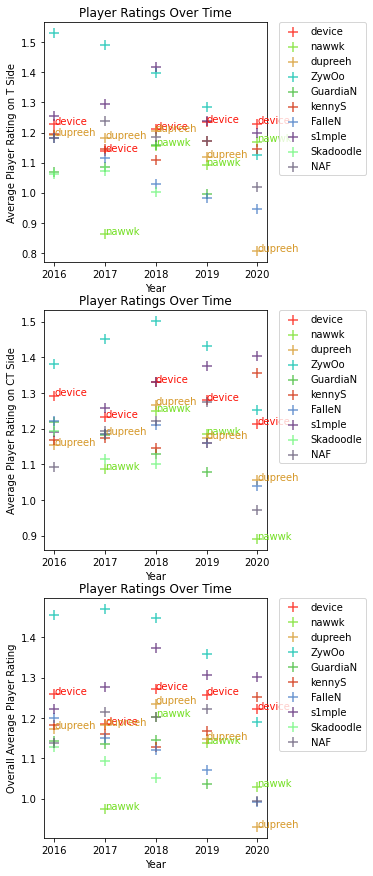

```python
fig0,ax0=plt.subplots(3,figsize=(4,15))
#We'll be comparing rating for the CT side, T side and overall separately, so we'll use 1 plot for each

ratings=['rating_t','rating_ct','rating_overall']#Just Store these in a list for convenience later on

for i in [0,1,2]:#Plot points then adjust Y-axis Labels and Title
    plot_scatter(ax0[i],ratings[i])
    if i==0:#Based on the graph, change the Y-axis label
        ax0[i].set_ylabel('Average Player Rating on T Side')
    elif i==1:
        ax0[i].set_ylabel('Average Player Rating on CT Side')
    elif i==2:
        ax0[i].set_ylabel('Overall Average Player Rating')

    ax0[i].set_title('Player Ratings Over Time')
```

From looking at these graphs and the DataFrame, we can see that actually the AWPing meta has shifted in a way since 2018, and most AWPers have been struggling to find their place and perform to the level that they once used to (though their ratings actually still are quite good). So maybe instead of using just raw rating, which may make comparing players difficult and confusing, we can show where players stand relative to others through their standardized rating, relative to the other AWPers we're comparing to.

Standardized values are generally given as (Value-Mean)/Standard Deviation, so we'll be calculating that based on year and statistic for every entry.

```python
rating_stats={}
for i in ratings:#For Each stat, collect the mean and standard deviation and put it in a pair
    yearly_stats = {}
    for y in np.unique(player_overall_yearly['year']):
        stats_year=player_overall_yearly.loc[player_overall_yearly['year']==y]
        yearly_stats[y]=(stats_year[i].mean(),stats_year[i].std())#store the tuple in a dictionary so we can use it later
    rating_stats[i]=yearly_stats
```

Now we have a dictionary of stats and breakdowns of those stats per year. For Example, if we wanted to get the mean and standard deviation of T Rating in 2018, we'd call (mean,stddev) = rating_stats['rating_t'][2018]. So we'll use that equation to calculate standardized values for all of the statistics for each entry.

```python
empty=np.empty_like(np.arange(len(player_overall_yearly)))
empty[:]=np.nan#Empty NaN list for the new values to be put in

standard_stats=['standard_rating_t','standard_rating_ct','standard_rating_overall']
for s in standard_stats:
    player_overall_yearly[s]=empty.astype(float)
#Now that we've made the space for the values, we can move on to the calculation

for i,e in player_overall_yearly.iterrows():
    for x in [0,1,2]:
        (m,std) = rating_stats[ratings[x]][e['year']]#pulls the mean and standard deviation out of the dictionaries
        player_overall_yearly.at[i,standard_stats[x]]=(e[ratings[x]]-m)/std#(value-mean)/stddev
```

We'll just be using our fancy plotting function to do the dirty work for us, and we'll fix the labels afterwards

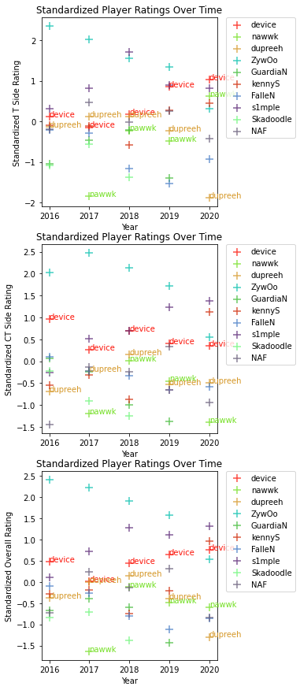

```python
fig1,ax1=plt.subplots(3,figsize=(4,15))
for i in [0,1,2]:
    plot_scatter(ax1[i],standard_stats[i])
    if i==0:#Based on the graph, change the Y-axis label
        ax1[i].set_ylabel('Standardized T Side Rating')
    elif i==1:
        ax1[i].set_ylabel('Standardized CT Side Rating')
    elif i==2:
        ax1[i].set_ylabel('Standardized Overall Rating')
    ax1[i].set_title('Standardized Player Ratings Over Time')
```

While it's difficult to gauge how worth it the trade was for Team Astralis because it was more of a sale, I wonder if it's possible to gauge how much NiP really needed an AWPer around the time of the acquisition.

```python
player_stats_nip=players_full.loc[players_full['team']=='NiP'].dropna()#Start out by getting just the NiP players
players_nip=np.unique(player_stats_nip['player_name'])#Easy list of all the NiP Players' name IDs
nip_awpers=['Delpan','f0rest','draken','nawwk','s1mple','allu','Maikelele','dennis','twist','dennis']
```

With this data, we're basically going to replicate what we did with the other players, but for the entire NiP team, differentiating AWPers and Riflers (nonAWPers).

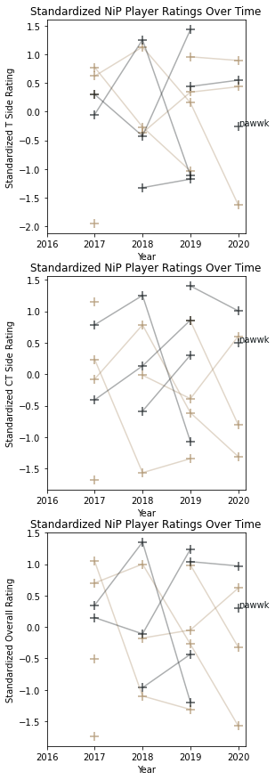

```python
def nip_stats_yearly(player_name,year):#We can automate this process for each pair of player and year
    players_year=player_stats_nip.loc[player_stats_nip['year']==year]#gets the DataFrame entries for that year
    avg_t=players_year.loc[players_year['player_name']==player_name]['rating_t'].mean()
    avg_ct=players_year.loc[players_year['player_name']==player_name]['rating_ct'].mean()
    return (avg_t,avg_ct)#Returns the 2 averages in a little package

#Create averages per year
data=[]
for p in players_nip:
    years_active=np.unique(player_stats_nip.loc[player_stats_nip['player_name']==p]['year'])
    for y in years_active:
        (avg_t,avg_ct) = nip_stats_yearly(p,y)
        summary=[p,y,avg_t,avg_ct,(avg_ct+avg_t)/2.]#assembles the entry for that player and year
        data.append(summary)

#Make a new DataFrame with the summarized values for each player per year
nip_overall_yearly=ps.DataFrame(data,columns=['player_name','year','rating_t','rating_ct','rating_overall'])

#Get Mean and Standard Deviations for them
rating_stats={}
for i in ratings:#For Each stat, collect the mean and standard deviation and put it in a pair
    yearly_stats = {}
    for y in np.unique(nip_overall_yearly['year']):
        stats_year=nip_overall_yearly.loc[nip_overall_yearly['year']==y]
        yearly_stats[y]=(stats_year[i].mean(),stats_year[i].std())#store the tuple in a dictionary so we can use it later
    rating_stats[i]=yearly_stats

#Standardize the ratings
for s in standard_stats:
    nip_overall_yearly[s]=empty[:len(nip_overall_yearly)].astype(float)
for i,e in nip_overall_yearly.iterrows():
    for x in [0,1,2]:
        (m,std) = rating_stats[ratings[x]][e['year']]#pulls the mean and standard deviation out of the dictionaries
        nip_overall_yearly.at[i,standard_stats[x]]=(e[ratings[x]]-m)/std#(value-mean)/stddev

def plot_scatter_nip(axn,stat):#Plot a certain statistic in the given graph
    #We're doing this because, as you'll soon see, we may need to do this multiple times
    for p in players_nip:
        player_yearly=nip_overall_yearly.loc[nip_overall_yearly['player_name']==p]
        if np.isin(p,nip_awpers):
            axn.scatter(player_yearly['year'],player_yearly[stat],marker='+',s=85,alpha=.75,color='#12191C',label=p)
            axn.plot(player_yearly['year'],player_yearly[stat],alpha=.35,color='#12191C',label=p)
            if p=='nawwk':
                for i,s in player_yearly.iterrows():
                    axn.annotate(p,(s['year'],s[stat]),color='#12191C')
        else:
            axn.scatter(player_yearly['year'],player_yearly[stat],marker='+',s=85,alpha=.75,color='#A98C66',label=p)
            axn.plot(player_yearly['year'],player_yearly[stat],alpha=.35,color='#A98C66',label=p)

        axn.set_xlabel('Year')#Change x-axis label
        plt.sca(axn)
        plt.xticks(np.arange(2016,2021))#Make the x-axis tick labels a bit cleaner

fig2,ax2=plt.subplots(3,figsize=(4,15))
for i in [0,1,2]:
    plot_scatter_nip(ax2[i],standard_stats[i])
    if i==0:#Based on the graph, change the Y-axis label
        ax2[i].set_ylabel('Standardized T Side Rating')
    elif i==1:
        ax2[i].set_ylabel('Standardized CT Side Rating')
    elif i==2:
        ax2[i].set_ylabel('Standardized Overall Rating')
    ax2[i].set_title('Standardized NiP Player Ratings Over Time')
```

From this graph, we can see 2 things, the first being that players don't stay active and in NiP for many years in a row, but also that actually nawwk was one of the better-performing players overall. With this information, it's hard for me to see why NiP would be interested in picking up an AWPer when, during 2020, their top performing player was an AWPer and 2 of the worst performing players were riflers (Not AWPer).

## Predictions of Match Outcome

When Dev1ce was on Astralis, he was surrounded by similarly star talent, many of the players being ranked in the top 20 in the whole CS:GO scene. I'm now interested to see how much of a difference the NiP team's performance would make on Dev1ce's performance, compared to the Astralis Team. Basically, can I use Machine Learning to predict how Dev1ce would perform on the team based on performance of his teammates? And could that performance be able to be translated into a possible win?

```python
astralis_stats=players_full[(players_full['team']=='Astralis') & (players_full['year']>=2018)]
astralis_stats=astralis_stats[['year','player_name','match_id','rating_t','rating_ct']].dropna()
device_stats=astralis_stats.loc[astralis_stats['player_name']=='device']#put device in his own DataFrame
astralis_stats=astralis_stats.loc[astralis_stats['player_name']!='device']#Remove device from the other one
```

To try and predict device's rating, we're going to use the average of the ratings for other 4 players on his team during each match.

```python
device_stats.index=device_stats['match_id']
empty=np.empty_like(np.arange(len(device_stats)))
empty[:]=np.nan
other_ratings=['other_t','other_ct']
for i in other_ratings:
    device_stats[i]=empty.astype(float)

for i,e in device_stats.iterrows():
    m_id=e['match_id']
    df=astralis_stats.loc[astralis_stats['match_id']==m_id]

    t=df['rating_t'].mean()
    ct=df['rating_ct'].mean()

    device_stats.at[m_id,'other_t']=t
    device_stats.at[m_id,'other_ct']=ct
```

To generate an accurate prediction regression equation, we're going to be using [SciPy](https://www.scipy.org/) and its machine learning algorithms.

```
Dev1ce has projected T-Side Rating of: 0.5640539701340194(Other Member's Average Rating)+0.5758695467311954
with p-value of: 2.306450406076468e-11
with r-squared value of: 0.15385687309870616
Dev1ce has projected CT-Side Rating of: 0.6164498892917303(Other Member's Average Rating)+0.5640050046535988
with p-value of: 1.1301826195012125e-12
with r-squared value of: 0.17235228766741612
```

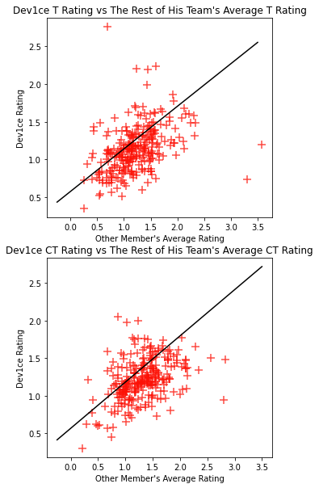

```python
reg_t=stats.linregress(device_stats['other_t'],device_stats['rating_t'])
reg_ct=stats.linregress(device_stats['other_ct'],device_stats['rating_ct'])

fig3,ax3=plt.subplots(2,figsize=(5,10))
for i in [0,1]:
    ax3[i].scatter(device_stats[ratings[i]],device_stats[other_ratings[i]],marker='+',s=85,alpha=.75,color='#FC1106',label=p)

    xs=np.linspace(-.25,3.5)

    ax3[i].set_xlabel('Other Member\'s Average Rating')#Change x-axis label
    ax3[i].set_ylabel('Dev1ce Rating')
    if i==0:
        ax3[i].plot(xs, reg_t.intercept + reg_t.slope*xs, 'black', label='Dev1ce\'s Predicted Rating')
        ax3[i].set_title('Dev1ce T Rating vs The Rest of His Team\'s Average T Rating')
    else:
        ax3[i].plot(xs, reg_ct.intercept + reg_ct.slope*xs, 'black', label='Dev1ce\'s Predicted Rating')
        ax3[i].set_title('Dev1ce CT Rating vs The Rest of His Team\'s Average CT Rating')

print('Dev1ce has projected T-Side Rating of: '+str(reg_t.slope)+'(Other Member\'s Average Rating)+'+str(reg_t.intercept))
print('with p-value of: '+str(reg_t.pvalue))
print('with r-squared value of: '+str(reg_t.rvalue**2))
print('Dev1ce has projected CT-Side Rating of: '+str(reg_ct.slope)+'(Other Member\'s Average Rating)+'+str(reg_ct.intercept))
print('with p-value of: '+str(reg_ct.pvalue))
print('with r-squared value of: '+str(reg_ct.rvalue**2))
```

While not surprising that there's a clear correlation between his teammate's average rating and his, Dev1ce's projected rating is still significantly higher than the averages, with the expected ratings when his team is doing literally nothing, or being rated at 0.0 being .58 and .56 (you should note that this is very extreme, and not actually meaningful since his teammates will never have an average rating of 0). This, paired with the "low" slope of the regression line means that Dev1ce tends not to be drug down by his teammates and that he performs very well on average even when his team isn't, and that he still benefits from having a team that is also performing well.

So what would we predict Dev1ce's ratings to be, based on NiP's average team ratings during games, and how does his rating compare to nawwk's and twist's(the previous AWPer for NiP before nawwk) real rating?

```python
#Repeat the last section but with nawwk and NiP replacing device and Astralis, respectively.
nip_stats=players_full[(players_full['team']=='NiP') & (players_full['year']>=2018)]
nip_stats=nip_stats[['year','player_name','match_id','rating_t','rating_ct']].dropna()
nawwk_stats=nip_stats.loc[nip_stats['player_name']=='nawwk']
twist_stats=nip_stats.loc[nip_stats['player_name']=='twist']
nip_stats=nip_stats[(nip_stats['player_name']!='nawwk') & (nip_stats['player_name']!='twist')]

nawwk_stats.index=nawwk_stats['match_id']
twist_stats.index=twist_stats['match_id']
empty=np.empty_like(np.arange(len(nawwk_stats)))
empty[:]=np.nan

for i in other_ratings:
    nawwk_stats[i]=empty.astype(float)

empty=np.empty_like(np.arange(len(twist_stats)))
empty[:]=np.nan

for i in other_ratings:
    twist_stats[i]=empty.astype(float)

#We're going to average the remaining players' ratings and store that into a new column for both nawwk and twist
for i,e in nawwk_stats.iterrows():
    m_id=e['match_id']
    df=nip_stats.loc[nip_stats['match_id']==m_id]

    t=df['rating_t'].mean()
    ct=df['rating_ct'].mean()

    nawwk_stats.at[m_id,'other_t']=t
    nawwk_stats.at[m_id,'other_ct']=ct

for i,e in twist_stats.iterrows():
    m_id=e['match_id']
    df=nip_stats.loc[nip_stats['match_id']==m_id]

    t=df['rating_t'].mean()
    ct=df['rating_ct'].mean()

    twist_stats.at[m_id,'other_t']=t
    twist_stats.at[m_id,'other_ct']=ct
```

```
Dev1ce has projected T-Side Rating of: 0.5640539701340194(Other Member's Average Rating)+0.5758695467311954
Dev1ce has projected CT-Side Rating of: 0.6164498892917303(Other Member's Average Rating)+0.5640050046535988
```

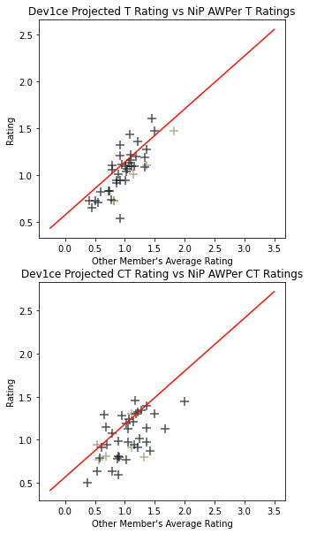

```python
fig4,ax4=plt.subplots(2,figsize=(5,10))
for i in [0,1]:
    ax4[i].scatter(nawwk_stats[ratings[i]],nawwk_stats[other_ratings[i]],marker='+',s=85,alpha=.75,color='#A98C66',label=p)
    ax4[i].scatter(twist_stats[ratings[i]],twist_stats[other_ratings[i]],marker='+',s=85,alpha=.75,color='#12191C',label=p)

    ax4[i].set_xlabel('Other Member\'s Average Rating')#Change x-axis label
    ax4[i].set_ylabel('Rating')
    if i==0:
        ax4[i].plot(xs, reg_t.intercept + reg_t.slope*xs, color='#FC1106', label='Dev1ce\'s Rating')
        ax4[i].set_title('Dev1ce Projected T Rating vs NiP AWPer T Ratings')
    else:
        ax4[i].plot(xs, reg_ct.intercept + reg_ct.slope*xs, color='#FC1106', label='Dev1ce\'s Rating')
        ax4[i].set_title('Dev1ce Projected CT Rating vs NiP AWPer CT Ratings')

print('Dev1ce has projected T-Side Rating of: '+str(reg_t.slope)+'(Other Member\'s Average Rating)+'+str(reg_t.intercept))
print('Dev1ce has projected CT-Side Rating of: '+str(reg_ct.slope)+'(Other Member\'s Average Rating)+'+str(reg_ct.intercept))
```

Conclusion and Closing Thoughts After all this work, it's hard for me to say that NiP's acquisition of star player Dev1ce was justified, I don't think that his arrival on the team will make much of a difference in performance and results in tournaments. While he has been performing well and better than the recent and current AWPers of NiP, that's not to say that he could magically make the team into the superstar team that the NiP organization wants them to be. Many of the graphs point towards the AWPers not really being large problems in the team performance, but rather the riflers and other players on the team. Even if NiP performed well, it did make me quite sad when I heard one of the most legendary rosters in CS:GO history was breaking up.

When I was writing the code and the explanations for each part, it really struck me just how difficult it is to truly represent how influential a person can be in a team, not just in terms of statistics, like rating and k/dr, but also in terms of synergy and team chemistry. I found myself wondering how I could represent someone's effect on a team's morale and playstyle, but I realized that's far too vague and difficult to explain or nail down properly. Overall, I think that maybe splitting up a squad with such strong chemistry and such iconic memories as Astralis may not have been for the best.

Thank you so much for taking the time read this! whether you're a TA, a professor, or just someone who stumbled upon this project, I really enjoy competitive eSports so finding a way to use my classes to analyze them maybe a bit more professionally was super fun, I hope the final product turned out to be at least a good read, or hopefully you learned something. Thanks again!

Class Website: [CMSC 320](https://cmsc320.github.io/)